# `R-INLA` sparsity preserving BYM2 implementation in `TMB`

Jeff Eaton (jeffrey.eaton@imperial.ac.uk)

Abstract

This document shows how to efficiently implement the BYM2 model in Template Model Builder (`TMB`) using a sparse representation.

# 1 `R-INLA` parameterisation for the BYM2 model

The BYM2 is a popular choice of model for spatial random effects. The Besag-York-Mollie (BYM) model decomposes a spatial random effect $\mathbf{x}$ into a spatially structured component $\mathbf{u}$ and an IID component $\mathbf{v}$. The BYM2 model reparameterises the BYM in terms of a marginal standard deviation $\sigma > 0$ and proportion $\phi \in [0,1]$ specifying the weight to each component:
$$\begin{align}
\mathbf{x} &= \sigma \cdot (\sqrt{\phi}\cdot \mathbf{u} + \sqrt{1-\phi}\cdot \mathbf{v}) \\
\mathbf{u} &\sim N(0, \mathbf{Q}^{-1}) \\
\mathbf{v} &\sim N(0, \mathbf{I}) \\
\end{align}$$
where the matrix $\mathbf{Q}$ is the scaled ICAR structure matrix such that $\mathrm{Var}(u_i) \approx 1$.

In most `TMB` implementations, we parameterise the BYM2 model in terms of the component random effects $\mathbf{u}$ and $\mathbf{v}$, as illustrated in the [tutorial on intrinsic area models in Stan](https://mc-stan.org/users/documentation/case-studies/icar_stan.html#bym2-improving-the-parameterization-of-the-besag-york-and-mollie-model) by Mitzi Morris.

The `R-INLA` implementation of the BYM2 model directly parameterises the spatial random effect $\mathbf{x}$, which has covariance matrix
$$\mathrm{Var}(\mathbf{x} | \sigma, \phi) = \sigma^2\cdot\left(\phi\cdot\mathbf{Q}^{-1} + (1-\phi)\cdot\mathbf{I}\right).$$

The inverse of $\mathrm{Var}(\mathbf{x} | \sigma, \phi)$, the precision matrix, is no longer sparse. To retain sparsity of the precision matrix, `R-INLA` parameterises the joint distribution of $(\mathbf{x}, \mathbf{u})$, described in Section 3.4 of [Reibler et al.](https://arxiv.org/pdf/1601.01180.pdf). Conditioning $\pi(\mathbf{x}, \mathbf{u}) = \pi(\mathbf{x} | \mathbf{u}) \pi(\mathbf{u})$ is used to derive that $\pi(\mathbf{x}, \mathbf{u})$ is a multivariate normal distribution with mean $\mathbf{0}$ and precision matrix
$$\left(\begin{array}{cc}
\frac{1}{\sigma^2 (1-\phi)} \mathbf{I} & -\frac{\sqrt{\phi}}{\sigma (1-\phi)} \mathbf{I} \\
-\frac{\sqrt{\phi}}{\sigma (1-\phi)} \mathbf{I} & \mathbf{Q} + \frac{\phi}{1-\phi} \mathbf{I}
\end{array}\right).$$

The normalising constant is apparent from the product of the normalising constants for the terms $\pi(\mathbf{x} | \mathbf{u})$ and $\pi(\mathbf{u})$:
$$(2\pi)^{-(n + \mathrm{rank}(\mathbf{Q}))/2} \cdot \left(\sigma \sqrt{1-\phi}\right)^{-n} \cdot |\mathbf{Q}|^{1/2}.$$

The terms $(2\pi)^{-(n + \mathrm{rank}(\mathbf{Q}))/2}$ and $|\mathbf{Q}|^{1/2}$ typically may be omitted. Further details of the derivation are on page 3 of the [notes accompanying the `R-INLA` documentation](https://github.com/hrue/r-inla/blob/devel/r-inla.org/doc/latent/bym2-details.pdf).

## 1.1 Benefit of directly parameterising $\mathbf{x}$

`TMB`, like `R-INLA`, implements a two step optimisation process. The “outer” optimisation step maximises the marginal posterior of the hyperparameters (referred to as “fixed” parameters in `TMB`). For each “outer” optimisation step, an “inner” optimisation maximises the latent field parameters (“random” parameters in `TMB` parlance) conditional on the hyperparameters, which is used to obtain a Gaussian approximation to the latent field posterior and thereby a Laplace approximation to the marginal posterior of the hyperparameters.

The starting values for each inner optimisation are the final optimised values from the previous iteration. Using the conventional parameterisation from the Morris tutorial, the linear predictor for an observation depends on the values of the hyperparameters, for example
$$\mu_i = \beta_0 + \sigma\cdot\left(\sqrt{\phi}\cdot u_i + \sqrt{1-\phi}\cdot v_i\right).$$
Thus a large step for the hyperparameters will affect the the value for the linear predictor $\mu_i$, potentially moving it far away from the optimal parameters.

If the random effect $x_i$ is directly parameterised as in the `R-INLA` implementation, for example $\mu_i = \beta_0 + x_i,$ the starting value for $\mu_i$ is unchanged by the updated hyperparameters. This change in parameterisation does not change the model (*i.e.* the inference for hyperparameters does not change), but the inner optimisation step may be more efficient by starting at parameter values closer to the final values.

## 1.2 Implementing the sparsity preserving parameterisation in `TMB`

`R-INLA` implements the BYM2 model parameterisation as a single vector $\mathbf{w} = (\mathbf{x}, \mathbf{u})$ of length $2n$, and constructs the full $2n \times 2n$ sparse precision matrix described above. Coding the sparse precision matrix and parsing the vector $\mathbf{w}$ in the `TMB` model template is an unnecessary hassle.

Instead, it is more convenient to decompose the block matrix multiplication:
$$\begin{align*}
\log \pi(\mathbf{x}, \mathbf{u} | \sigma,\phi) &= -\frac{n+\mathrm{rank}(\mathbf{Q})}{2}
\log(2\pi) - n\log(\sigma) - \frac{n}{2} \log(1-\phi) + \frac{1}{2}\log|\mathbf{Q}| -
\frac{1}{2} \left(\begin{array}{cc}\mathbf{x}' & \mathbf{u}'\end{array}\right)
\left(\begin{array}{cc}
\frac{1}{\sigma^2 (1-\phi)} \mathbf{I} & -\frac{\sqrt{\phi}}{\sigma (1-\phi)} \mathbf{I} \\
-\frac{\sqrt{\phi}}{\sigma (1-\phi)} \mathbf{I} & \mathbf{Q} + \frac{\phi}{1-\phi} \mathbf{I}
\end{array}\right)
\left(\begin{array}{c} \mathbf{x} \\ \mathbf{u}\end{array}\right) \\
&= C - \frac{1}{2}\left[\mathbf{x}' \left(\frac{1}{\sigma^2 (1-\phi)} \mathbf{I}\right)\mathbf{x} -
2\mathbf{x}'\left(\frac{\sqrt{\phi}}{\sigma (1-\phi)} \mathbf{I}\right)\mathbf{u} +
\mathbf{u}'\left(\mathbf{Q} + \frac{\phi}{1-\phi} \mathbf{I}\right) \mathbf{u}\right] \\
&= -\frac{n+\mathrm{rank}(\mathbf{Q})}{2}
\log(2\pi) - n\log(\sigma) - \frac{n}{2} \log(1-\phi) + \frac{1}{2}\log|\mathbf{Q}| -
\frac{\mathbf{x}'\mathbf{x}}{2\sigma^2(1-\phi)} +
\frac{\sqrt{\phi}\mathbf{x}'\mathbf{u}}{\sigma (1-\phi)} -
\frac{\phi \mathbf{u}'\mathbf{u}}{2\cdot(1-\phi)} -
\frac{1}{2}\mathbf{u}'\mathbf{Q}\mathbf{u}
\end{align*}$$
The constant terms $-\frac{n+\mathrm{rank}(\mathbf{Q})}{2}\log(2\pi)$ and $\frac{1}{2}\log|\mathbf{Q}|$ typically need not be computed.

# 2 Example: Scottish Lip Cancer dataset

## 2.1 Preliminaries

Load libraries and utility functions.

```r
library(tidyverse)
library(INLA)
library(TMB)
```

```r
tmb_compile_and_load <- function(code) {
  f <- tempfile(fileext = ".cpp")
  writeLines(code, f)
  TMB::compile(f)
  dyn.load(TMB::dynlib(tools::file_path_sans_ext(f)))
  basename(tools::file_path_sans_ext(f))
}
```

## 2.2 Scottish Lip Cancer Data

Use the version of Scottish lip cancer dataset used by Mitzi Morris for the [tutorial on ICAR models in Stan](https://mc-stan.org/users/documentation/case-studies/icar_stan.html).

```r
source("https://raw.githubusercontent.com/stan-dev/example-models/master/knitr/car-iar-poisson/scotland_data.R")
scotlip <- data
```

The list `scotlip` consists of items:

- `N`: number of regions,
- `y`: observed counts of lip cancer cases per county,
- `E`: the expected number of cases, used as an offset,
- `x`: continuous covariate representing the proportion of the population employed in agriculture, fishing, or forestry (AFF),
- `adj`: a vector of region ids for adjacent regions,
- `weights`: weight for each edge (all `1`s),
- `num`: the number of neighbors for each region, used to split `adj`.

Scale the covariate `x` as in Morris tutorial.

```r
scotlip$x_scaled <- 0.1 * scotlip$x
```

Parse the adjacency list into an adjacency matrix.

```r
nblist <- cbind(rep(seq_len(scotlip$N), times = scotlip$num),
                scotlip$adj)
adj <- matrix(0, nrow = scotlip$N, ncol = scotlip$N)
adj[nblist] <- 1
```

Construct the scaled structure matrix for ICAR model precision.

```r
Q <- diag(rowSums(adj)) - adj
Q_scaled <- inla.scale.model(Q, constr = list(A = matrix(1, ncol = ncol(Q)), e = 0))
```

Prepare a list of `TMB` model inputs.

```r
tmbdata <- list(region = 1:scotlip$N,
                y = scotlip$y,
                x = scotlip$x_scaled,
                E = scotlip$E,
                Q = Q_scaled)
```

## 2.3 Morris parameterisation: $\mathbf{u}$ and $\mathbf{v}$

The `TMB` model template `mod1` below implements the model
$$\begin{align}
y_i &\sim \mathrm{Poisson}(\eta_i) \\
\log \eta_i &= \beta_0 + \beta_1 \cdot x + b_i + \log E_i \\
\mathbf{b} &= \sigma \cdot \left(\sqrt{\phi}\cdot \mathbf{u} + \sqrt{1-\phi}\cdot \mathbf{v}\right) \\
\mathbf{u} &\sim N(0, \mathbf{Q}^{-1}) \\
\mathbf{v} &\sim N(0, \mathbf{I}) \\
\sigma &\sim N^{+}(0, 1) \\
\phi &\sim \mathrm{Beta}(0.5, 0.5)
\end{align}$$

```r
mod1 <- '
#include <TMB.hpp>

template<class Type>
Type objective_function<Type>::operator() ()
{

  DATA_VECTOR(y);
  DATA_VECTOR(x);
  DATA_VECTOR(E);

  DATA_SPARSE_MATRIX(Q); // Structure matrix for ICAR area model

  Type val(0);

  PARAMETER(beta0);  // intercept
  PARAMETER(beta1);  // slope
  // beta0 ~ 1
  // beta1 ~ 1

  PARAMETER(log_sigma); // marginal standard deviation
  Type sigma(exp(log_sigma));
  val -= dnorm(sigma, Type(0.0), Type(1.0), true) + log_sigma;

  PARAMETER(logit_phi);
  Type phi(invlogit(logit_phi));
  val -= log(phi) +  log(1 - phi);  // change of variables: logit_phi -> phi
  val -= dbeta(phi, Type(0.5), Type(0.5), true);

  PARAMETER_VECTOR(u); // spatially correlated component
  val -= Type(-0.5) * (u * (Q * u)).sum();

  // soft sum-to-zero constraint
  val -= dnorm(u.sum(), Type(0.0), Type(0.001) * u.size(), true);

  PARAMETER_VECTOR(v); // unstructured component
  val -= dnorm(v, Type(0.0), Type(1.0), true).sum();

  // combined spatial effect
  vector<Type> b(sigma * (sqrt(phi) * u + sqrt(1 - phi) * v));

  vector<Type> mu(beta0 + beta1 * x + b + log(E));
  val -= dpois(y, exp(mu), true).sum();

  ADREPORT(sigma);
  ADREPORT(phi);
  ADREPORT(b);
  ADREPORT(mu);

  return val;
}
'
```

Compile and fit the `TMB` model.

```r
dll1 <- tmb_compile_and_load(mod1)
```

Initial values for parameters.

```r
tmbpar1 <- list(beta0 = 0,
                beta1 = 0,
                log_sigma = 0,
                logit_phi = 0,
                u = numeric(scotlip$N),
                v = numeric(scotlip$N))
```

Create `TMB` object and optimise parameters.

```r
obj1 <- TMB::MakeADFun(data = tmbdata,
                       parameters = tmbpar1,
                       random = c("beta0", "beta1", "u", "v"),
                       DLL = dll1)

tmbfit1 <- nlminb(obj1$par, obj1$fn, obj1$gr)

sdr1 <- TMB::sdreport(obj1)
```

Estimates for intercept and slope and hyperparameters.

```r
summary(sdr1, "all") %>%
  .[rownames(.) %in% c("log_sigma", "logit_phi", "beta0", "beta1"), ]
```

```
##             Estimate Std. Error
## log_sigma -0.6863323  0.1647692
## logit_phi  1.8638959  1.4347334
## beta0     -0.1912772  0.1253730
## beta1      0.3771592  0.1305491
```

## 2.4 2. `R-INLA` parameterisation: $\mathbf{b}$ and $\mathbf{u}$

The `TMB` model template `mod2` below implements the `R-INLA` parameterisation of the same model described in Section 3.4 of Reibler et al.:
$$\begin{align}
y_i &\sim \mathrm{Poisson}(\eta_i) \\
\log \eta_i &= \beta_0 + \beta_1 \cdot x + b_i + \log E_i \\
(\mathbf{b}, \mathbf{u}) &\sim N(0, \mathbf{\Sigma}(\sigma, \phi)) \\
\sigma &\sim N^{+}(0, 1) \\
\phi &\sim \mathrm{Beta}(0.5, 0.5)
\end{align}$$
where the precision matrix $\mathbf{\Sigma}^{-1}(\sigma, \phi)$ is as defined above.

```r
mod2 <- '
#include <TMB.hpp>

template<class Type>
Type objective_function<Type>::operator() ()
{

  DATA_VECTOR(y);
  DATA_VECTOR(x);
  DATA_VECTOR(E);

  DATA_SPARSE_MATRIX(Q); // Structure matrix for ICAR area model

  Type val(0);

  PARAMETER(beta0);  // intercept
  PARAMETER(beta1);  // intercept
  // beta0 ~ 1
  // beta1 ~ 1

  PARAMETER(log_sigma); // marginal standard deviation
  Type sigma(exp(log_sigma));
  val -= dnorm(sigma, Type(0.0), Type(1.0), true) + log_sigma;

  PARAMETER(logit_phi);
  Type phi(invlogit(logit_phi));
  val -= log(phi) +  log(1 - phi);  // change of variables: logit_phi -> phi
  val -= dbeta(phi, Type(0.5), Type(0.5), true);

  PARAMETER_VECTOR(b); // combined spatial effect

  PARAMETER_VECTOR(u); // spatially correlated component
  val -= dnorm(u.sum(), Type(0.0), Type(0.001) * u.size(), true); // soft sum-to-zero constraint

  // -(n + rank(Q)) / 2 * log(2*pi) and log|Q| / 2 terms omitted
  val -= -0.5 * b.size() * (2 * log_sigma + log(1 - phi));          // normalising constant
  val -= -0.5 * (b * b).sum() / (sigma * sigma * (1 - phi));
  val -= (b * u).sum() * sqrt(phi) / (sigma * (1 - phi));
  val -= -0.5 * (u * u).sum() * phi / (1 - phi);
  val -= -0.5 * (u * (Q * u)).sum();

  vector<Type> mu(beta0 + beta1 * x + b + log(E));
  val -= dpois(y, exp(mu), true).sum();

  ADREPORT(sigma);
  ADREPORT(phi);
  ADREPORT(mu);

  return val;
}
'
```

Compile and fit model 2.

```r
dll2 <- tmb_compile_and_load(mod2)

tmbpar2 <- list(beta0 = 0,
                beta1 = 0,
                log_sigma = 0,
                logit_phi = 0,
                b = numeric(scotlip$N),
                u = numeric(scotlip$N))

obj2 <- TMB::MakeADFun(data = tmbdata,
                       parameters = tmbpar2,
                       random = c("beta0", "beta1", "b", "u"),
                       DLL = dll2)

tmbfit2 <- nlminb(obj2$par, obj2$fn, obj2$gr)

sdr2 <- TMB::sdreport(obj2)
```

## 2.5 Compare estimates

Estimates for intercept and slope and hyperparameters match exactly with the Morris parameterisation.

```r
summary(sdr1, "all") %>%
  .[rownames(.) %in% c("log_sigma", "logit_phi", "beta0", "beta1"), ]
```

```
##             Estimate Std. Error
## log_sigma -0.6863323  0.1647692
## logit_phi  1.8638959  1.4347334
## beta0     -0.1912772  0.1253730
## beta1      0.3771592  0.1305491
```

```r
summary(sdr2, "all") %>%
  .[rownames(.) %in% c("log_sigma", "logit_phi", "beta0", "beta1"), ]
```

```
##             Estimate Std. Error
## log_sigma -0.6863323  0.1647692
## logit_phi  1.8638959  1.4347334
## beta0     -0.1912772  0.1253730
## beta1      0.3771592  0.1305491
```

The scatter plot of point estimates and posterior standard deviation for the random effects $b_i$ and $u_i$ show these are also identical.

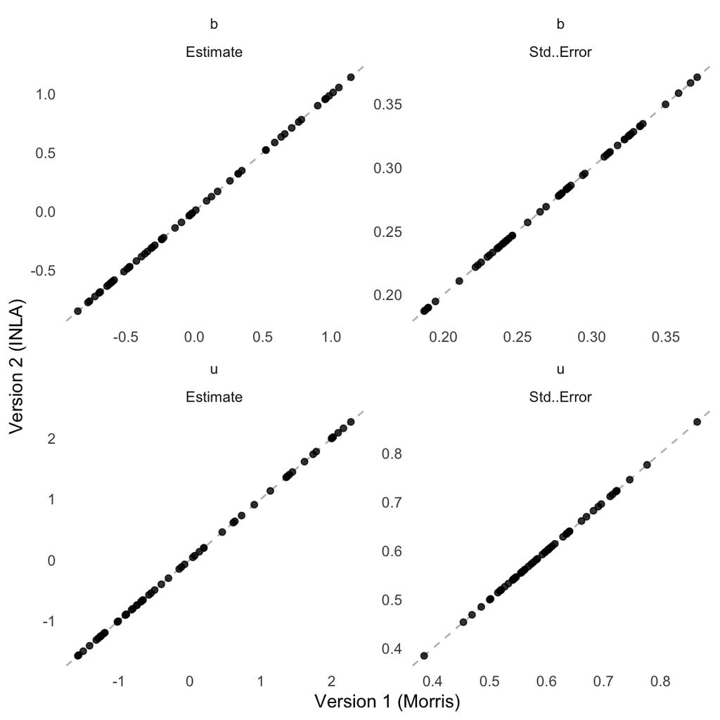

## 2.6 Check `TMB` results with `R-INLA`

The `TMB` models above conduct the same inference as `R-INLA` using the options `control.inla = list(strategy = "gaussian", int.strategy = "eb")`.

```r
priors <- list(phi = list(prior = "logitbeta", params = c(0.5, 0.5)),
               prec = list(prior = "logtnormal", params = c(0, 1.0)))

inla_formula <- y ~ 1 + x +
  f(region, model = "bym2", graph = adj, hyper = priors, constr = TRUE)

inla_eb <- inla(inla_formula, family = "poisson", E = E,
                data = tmbdata[c("region", "y", "x", "E")],
                control.fixed = list(prec = 1/25, prec.intercept = 1/25),
                control.inla = list(strategy = "gaussian", int.strategy = "eb"))
```

Estimates and standard errors for the fixed effects and hyperparameters from `TMB` are close to the mode and sd reported by `R-INLA`. The log precision is -2 times the `log_sigma` parameter in the `TMB` models.

```r
inla_eb$internal.summary.hyperpar
```

|  | mean | sd | 0.025quant | 0.5quant | 0.975quant | mode |
| --- | --- | --- | --- | --- | --- | --- |
| Log precision for region | 1.358965 | 0.328396 | 0.71273119 | 1.358614 | 2.006750 | NA |
| Logit phi for region | 2.630265 | 1.553042 | -0.03925673 | 2.480375 | 6.008166 | NA |

```r
inla_eb$summary.fixed
```

|  | mean | sd | 0.025quant | 0.5quant | 0.975quant | mode | kld |
| --- | --- | --- | --- | --- | --- | --- | --- |
| (Intercept) | -0.1901015 | 0.1229375 | -0.4310547 | -0.1901015 | 0.05085163 | NA | 0 |
| x | 0.3756609 | 0.1260428 | 0.1286217 | 0.3756609 | 0.62270018 | NA | 0 |

Point estimates for random effect estimates are exactly the same for `TMB` and the `R-INLA` empirical Bayes estimates. The posterior standard deviations are highly correlated but slightly larger for the `TMB` estimates than `R-INLA`.

[figure not shown]

# 3 Full Bayesian inference

The point estimates from the `TMB` and `R-INLA` models above are slightly different from [those reported in the Morris tutorial](https://mc-stan.org/users/documentation/case-studies/icar_stan.html#bym2-improving-the-parameterization-of-the-besag-york-and-mollie-model) using full Bayesian inference in Stan or `R-INLA`.

These are reproduced by changing the strategy to `control.inla = list(strategy="laplace")`.

```r
inla_full <- inla(inla_formula, family = "poisson", E = E,
                  data = tmbdata[c("region", "y", "x", "E")],
                  control.fixed = list(prec = 1/25, prec.intercept = 1/25),
                  control.inla = list(strategy="laplace"))

inla_full$summary.fixed
```

|  | mean | sd | 0.025quant | 0.5quant | 0.975quant | mode | kld |
| --- | --- | --- | --- | --- | --- | --- | --- |
| (Intercept) | -0.2206922 | 0.1257537 | -0.4683835 | -0.2206250 | 0.02648608 | NA | 3.755622e-08 |
| x | 0.3697554 | 0.1312118 | 0.1065741 | 0.3715513 | 0.62293530 | NA | 2.860152e-08 |

```r
inla_full$internal.summary.hyperpar
```

[output not shown]

The package [`tmbstan`](https://github.com/kaskr/tmbstan) can be used to sample from the posterior distribution with the `TMB` model objects created above.

```r
library(tmbstan)

stanfit1 <- tmbstan(obj1, refresh = 0)
stanfit2 <- tmbstan(obj2, refresh = 0)

print(stanfit1, digits = 3, par = c("beta0", "beta1", "log_sigma", "logit_phi", "lp__"))
```

```
## Inference for Stan model: file18022163e345.
## 4 chains, each with iter=2000; warmup=1000; thin=1;
## post-warmup draws per chain=1000, total post-warmup draws=4000.
##
##               mean se_mean    sd     2.5%      25%      50%      75%    97.5%
## beta0       -0.220   0.003 0.124   -0.468   -0.301   -0.219   -0.137    0.024
## beta1        0.368   0.004 0.129    0.108    0.283    0.369    0.454    0.631
## log_sigma   -0.678   0.007 0.160   -0.996   -0.783   -0.678   -0.574   -0.358
## logit_phi    3.110   0.094 2.267   -0.165    1.536    2.706    4.224    8.825
## lp__      -243.431   0.281 8.889 -261.710 -249.285 -243.222 -237.306 -226.838
##           n_eff  Rhat
## beta0      1283 1.001
## beta1      1121 1.002
## log_sigma   489 1.013
## logit_phi   581 1.009
## lp__       1003 1.000
##
## Samples were drawn using NUTS(diag_e) at Wed Oct 19 13:48:51 2022.
## For each parameter, n_eff is a crude measure of effective sample size,
## and Rhat is the potential scale reduction factor on split chains (at
## convergence, Rhat=1).
```

```r
print(stanfit2, digits = 3, par = c("beta0", "beta1", "log_sigma", "logit_phi", "lp__"))
```

```
## Inference for Stan model: file180224432a09.
## 4 chains, each with iter=2000; warmup=1000; thin=1;
## post-warmup draws per chain=1000, total post-warmup draws=4000.
##
##              mean se_mean     sd     2.5%      25%     50%     75%   97.5%
## beta0      -0.223   0.003  0.128   -0.474   -0.310  -0.224  -0.138   0.023
## beta1       0.373   0.004  0.133    0.103    0.286   0.378   0.460   0.627
## log_sigma  -0.678   0.004  0.162   -1.003   -0.786  -0.675  -0.573  -0.359
## logit_phi   2.410   0.165  1.338   -0.085    1.467   2.363   3.299   5.017
## lp__      -81.471   4.016 31.951 -135.900 -105.626 -83.772 -60.819 -14.913
##           n_eff  Rhat
## beta0      1547 1.002
## beta1      1378 1.003
## log_sigma  1519 1.001
## logit_phi    66 1.063
## lp__         63 1.069
##
## Samples were drawn using NUTS(diag_e) at Wed Oct 19 13:49:46 2022.
## For each parameter, n_eff is a crude measure of effective sample size,
## and Rhat is the potential scale reduction factor on split chains (at
## convergence, Rhat=1).
```

The estimates from `stanfit1`, using the Morris tutorial parameterisation, match closely to the full `R-INLA` results.

For the second parameterisation, the $\hat R$ estimate for the `logit_phi` parameter is large and the number of effective samples is low, indicating poor convergence for this parameter. This highlights that direct parameterisation of $\mathbf{b}$ is not optimal for HMC inference, at least in this case.